## Most asian parents tell their children :

#### Higher Education +

#### Work Hard +

#### Happy Marriage =

#### **Good Life**

### ?

### ? Myth or Fact ?

### ?

### I know, I know, a **Good Life** is **NOT** identical to …

### But, be honest, you know and I know, we need some to have a **Good Life**.

### Using **R** and **ggplot2**, and visually exploring the *Adult* dataset from *UC Irvine Machine Learning Repository*, I may become the Myth Buster of :

### + + =

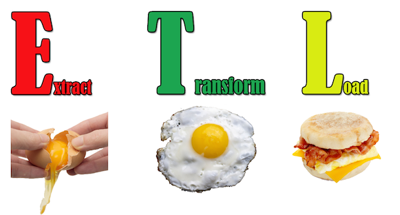

- The *Adult* dataset is originally used to predict whether income exceeds $50K/year, based on 1994 census data. Information can be found at http://archive.ics.uci.edu/ml/datasets/Adult.
- The *Adult* dataset can be downloaded at [http://archive.ics.uci.edu/ml/machine-learning-databases/adult/adult.datahttp://archive.ics.uci.edu/ml/machine-learning-databases/adult/adult.data](http://archive.ics.uci.edu/ml/machine-learning-databases/adult/adult.data).
- The *Adult* dataset uses ", " (comma followed by one space) as field separator. I transform it to "," (a single comma).
- The *Adult* dataset uses "?" for missing values. I transform it with "NA".
- I load the *Adult* dataset to data frame *adult* which has 15 attributes and 32561 observations.

```r
dim(adult)
```

```
## [1] 32561    15
```

- I remove NA rows and then it has 15 attributes and 30162 observations.

```r
dim(adult)
```

```
## [1] 30162    15
```

- I give each attribute a name:

```r
colnames(adult) = c(
'age', 'workclass', 'fnlwgt', 'education', 'education_num',
'marital_status', 'occupation', 'relationship', 'race', 'sex',
'capital_gain', 'capital_loss', 'hours_per_week',
'native_country', 'class')
colnames(adult)
```

```
##  [1] "age"            "workclass"      "fnlwgt"         "education"
##  [5] "education_num"  "marital_status" "occupation"     "relationship"
##  [9] "race"           "sex"            "capital_gain"   "capital_loss"
## [13] "hours_per_week" "native_country" "class"
```

- I rename *Marital Status* for better display and counting:

```r
levels(adult$marital_status)[levels(adult$marital_status)
   =="Divorced"] = "Divor"
levels(adult$marital_status)[levels(adult$marital_status)
   =="Married-AF-spouse"] = "Marri"
levels(adult$marital_status)[levels(adult$marital_status)
   =="Married-civ-spouse"] = "Marri"
levels(adult$marital_status)[levels(adult$marital_status)
   =="Married-spouse-absent"] = "Marri"
levels(adult$marital_status)[levels(adult$marital_status)
   =="Never-married"] = "Never"
levels(adult$marital_status)[levels(adult$marital_status)
   =="Separated"] = "Separ"
levels(adult$marital_status)[levels(adult$marital_status)
   =="Widowed"] = "Widow"
levels(adult$marital_status)
```

```
## [1] "Divor" "Marri" "Never" "Separ" "Widow"
```

- I rename *Work Class* for better display and counting:

```r
levels(adult$workclass)[levels(adult$workclass)=="Federal-gov"] ="GOV"
levels(adult$workclass)[levels(adult$workclass)=="Local-gov"] = "GOV"
levels(adult$workclass)[levels(adult$workclass)=="Never-worked"] =
  "NEVER"
levels(adult$workclass)[levels(adult$workclass)=="Private"] = "PRIV"
levels(adult$workclass)[levels(adult$workclass)=="Self-emp-inc"] =
  "SELF"
levels(adult$workclass)[levels(adult$workclass)=="Self-emp-not-inc"] =
  "SELF"
levels(adult$workclass)[levels(adult$workclass)=="State-gov"] = "GOV"
levels(adult$workclass)[levels(adult$workclass)=="Without-pay"] =
  "NOPAY"
levels(adult$workclass)
```

```
## [1] "GOV"   "NEVER" "PRIV"  "SELF"  "NOPAY"
```

- I add numeric "Ed Level" based on factor "Education":

```r
adult = mutate(adult, ed_level = 0)
obs = nrow(adult)
for (i in 1:obs) {
    switch(adult$education[i],
      "Preschool" = { adult$ed_level[i] = 1 },
      "1st-4th" = { adult$ed_level[i] = 2 },
      "5th-6th" = { adult$ed_level[i] = 3 },
      "7th-8th"= { adult$ed_level[i] = 3 },
      "9th" = { adult$ed_level[i] = 4 },
      "10th" = { adult$ed_level[i] = 4 },
      "11th" = { adult$ed_level[i] = 4 },
      "12th" = { adult$ed_level[i] = 4 },
      "HS-grad"  = { adult$ed_level[i] = 4 },
```

```r
      "Some-college" = { adult$ed_level[i] = 4 },
      "Assoc-acdm"  = { adult$ed_level[i] = 5 },
      "Assoc-voc" = { adult$ed_level[i] = 5 },
      "Prof-school" = { adult$ed_level[i] = 5 },
      "Bachelors"  = { adult$ed_level[i] = 6 },
      "Masters" = { adult$ed_level[i] = 7 },
      "Doctorate" = { adult$ed_level[i] = 8 })}
```

- I use numeric *Education Years* from original dataset as education indicator since it agrees with factor *Education*.

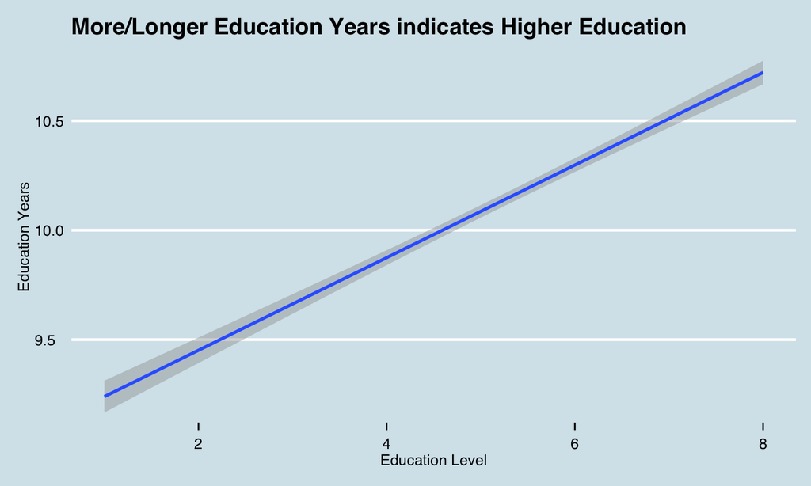

- I single asian out from *adult* into data frame *asian_adult*:

```r
levels(adult$race)
```

```
## [1] "Amer-Indian-Eskimo" "Asian-Pac-Islander" "Black"
## [4] "Other"              "White"
```

```r
summarise( group_by(adult, race), n())
```

```
## # A tibble: 5 × 2
##                 race `n()`
##               <fctr> <int>
## 1 Amer-Indian-Eskimo   286
## 2 Asian-Pac-Islander   895
## 3              Black  2817
## 4              Other   231
## 5              White 25933
```

```r
asian_adult = adult[adult$race == "Asian-Pac-Islander",]
```

- I further single out asian adult working in private section since this sector has more asian adult.

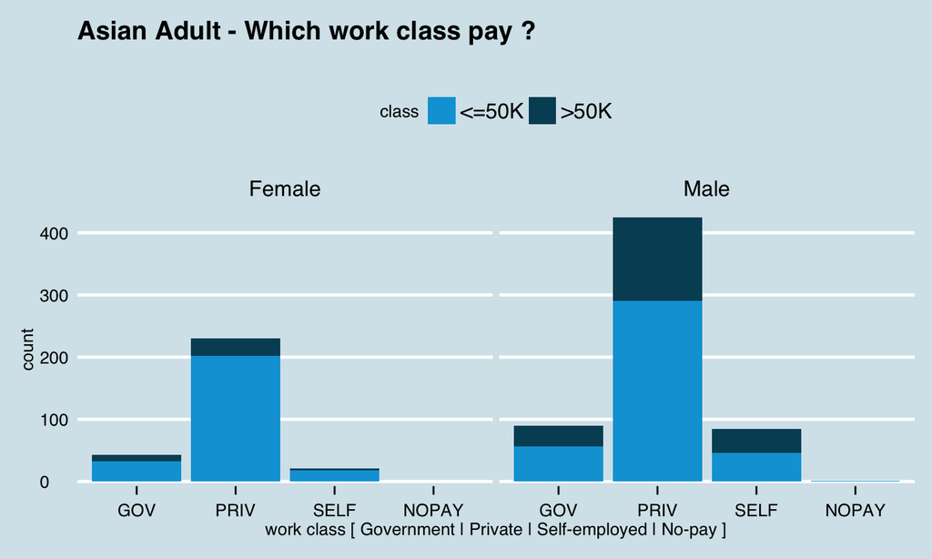

+ + = ???

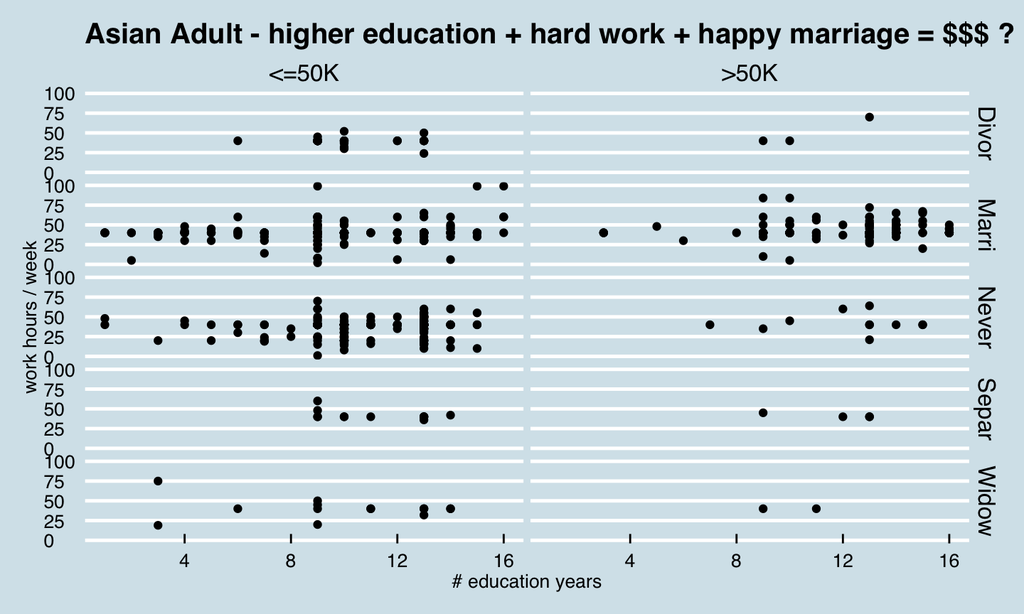

-Dad & Mom: You are right.

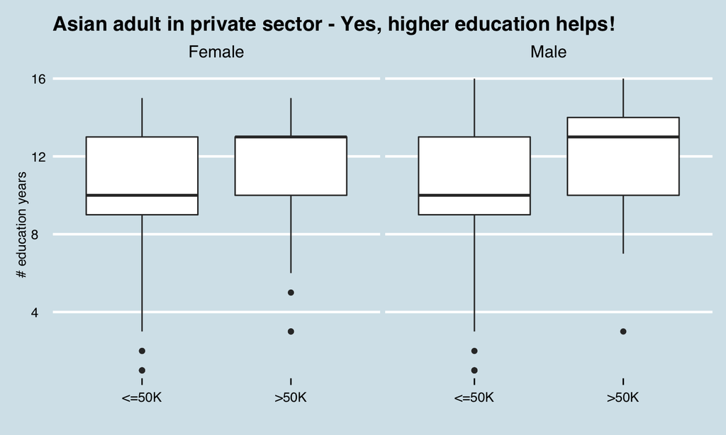

-Dad & Mom: You are right about boys.

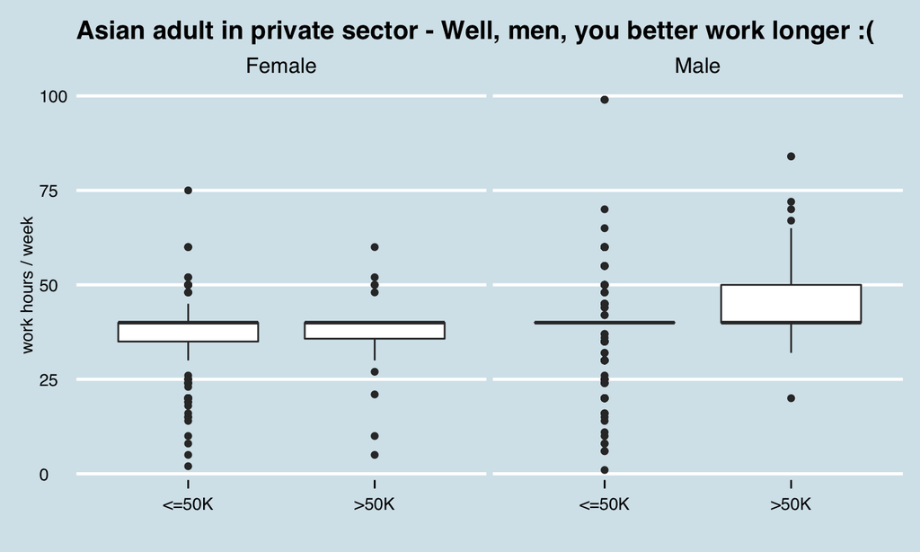

-Dad & Mom: You are right again!

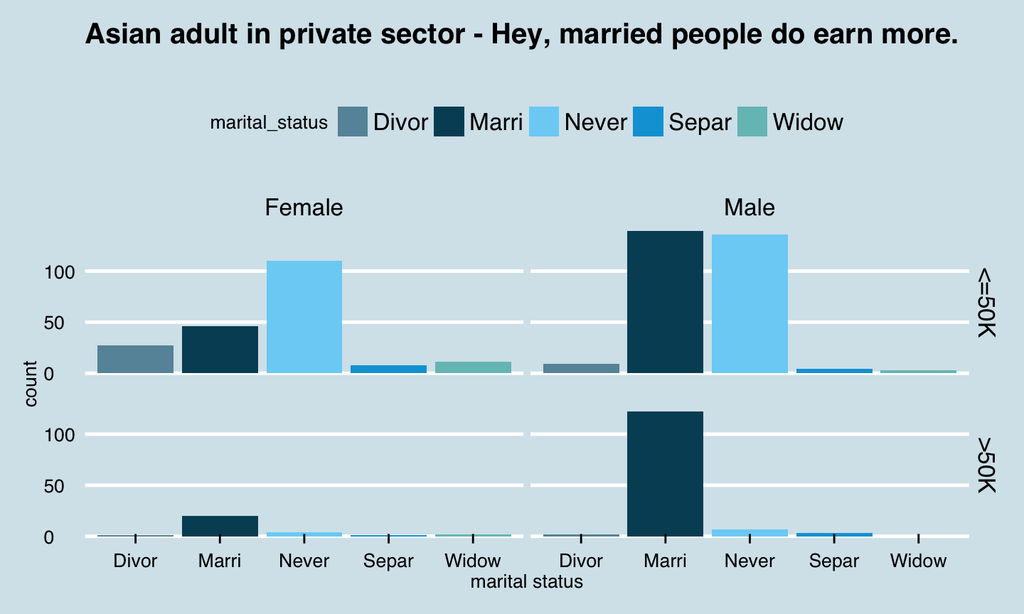

## A few thoughts

Two out of three ain't bad, right? But, I won't conclude the formula is a fact, as I think the asian adult sample in 1994 *Adult* dataset (895) seems too small. A conclusion should be drawn after explored more samples from multiple years.

As an asian myself, I listen and obey my parents as they always want the best for me. Most things change as time evolves; thus, it is reasonable to say very few things hold true forever. But, parents' care for their children never change.

You may ask, "Are you sure?" **"Yes, because I told you so!!!"**

Sincerely, Conred Wang.